# Application to GREAT data

Thomas Debray

Aug 27, 2019

# Introduction

## Case study

We will use a simulated Individual Patient Data (IPD) meta-analysis with missing values. This dataset is a simulated version of an IPD meta-analysis consisting of 28 studies focusing on risk factors in acute heart failure (GREAT Network, 2013). Managing acute heart failure in the ed - case studies from the acute heart failure academy. http://www.greatnetwork.org). Each study includes a list of patient characteristics and potential risk factors. Each of them is incomplete, leading to sporadically missing values (Resche-Rigon, et al 2013). In addition, some variables have been collected on some studies only, leading to systematically missing values. More details on the original dataset are provided in Audigier et al. (2018). To mimic the real data, a general location model has been fitted on each study (Schafer, 1997). Then, each study has been generated according to the estimated parameters. Finally, missing values have been allocated similarly to the original dataset.

## Prerequisites

We first load the necessary packages

```r
library(MASS)
library(reshape2)
library(ggplot2)
library(mice)
library(micemd)
library(mitml)
library(jomo)
library(lme4)
library(dplyr)
library(metafor)
```

## Configuration

```r
set.seed(113393)

# parameters
main_fmla <- "lvef ~ bnp + afib"
main_fmla_1stage <- "lvef ~ bnp + afib + (bnp|centre)"
var_monitor <- c("bmi", "bnp","afib")
n_burnin <- 10000
n_between <- 5000
n_impute <- 10 # how many imputed datasets to generate?
maxit_impute <- 20
```

# GREAT data

The GREAT data contains 11685 observations on the following 10 variables.

- centre: a numeric indexing the center where the study is conducted
- gender: a factor with levels 0 1
- bmi: a numeric vector indicating the body mass index
- age: a numeric vector indicating the age
- sbp: a numeric vector indicating the systolic blood pressure
- dbp: a numeric vector indicating the diastolic blood pressure
- hr: a numeric vector indicating the heart rate
- lvef: a numeric vector indicating the ventricular ejection fraction
- bnp: a numeric vector indicating the level of the brain natriuretic peptide biomarker
- afib: a factor with levels 0 1 indicating the atrial fibrillation

```r
data(IPDNa)
by(IPDNa,IPDNa$centre,summary)
```

```
## IPDNa$centre: 1
##      centre  gender       bmi             age              sbp
##  Min.   :1   0:203   Min.   :15.11   Min.   : 50.00   Min.   : 71.0
##  1st Qu.:1   1:207   1st Qu.:24.26   1st Qu.: 64.00   1st Qu.:121.0
##  Median :1           Median :28.07   Median : 71.50   Median :142.0
##  Mean   :1           Mean   :28.49   Mean   : 72.17   Mean   :143.5
##  3rd Qu.:1           3rd Qu.:31.35   3rd Qu.: 79.00   3rd Qu.:163.0
##  Max.   :1           Max.   :48.18   Max.   :100.00   Max.   :247.0
##                      NA's   :148     NA's   :8        NA's   :4
##       dbp               hr              lvef            bnp
##  Min.   : 16.00   Min.   : 30.00   Min.   :0.110   Min.   :1.855
##  1st Qu.: 68.00   1st Qu.: 74.00   1st Qu.:0.320   1st Qu.:2.671
##  Median : 82.00   Median : 88.00   Median :0.415   Median :2.934
##  Mean   : 81.38   Mean   : 92.11   Mean   :0.452   Mean   :3.008
##  3rd Qu.: 95.00   3rd Qu.:108.00   3rd Qu.:0.560   3rd Qu.:3.343
##  Max.   :142.00   Max.   :194.00   Max.   :1.000   Max.   :4.421
##  NA's   :8        NA's   :12                       NA's   :235
##    afib
##  0   :323
##  1   : 86
##  NA's:  1
##
##
##
##
## --------------------------------------------------------
## IPDNa$centre: 2
##      centre  gender       bmi             age              sbp
##  Min.   :2   0:319   Min.   :14.98   Min.   : 36.00   Min.   : 67.0
##  1st Qu.:2   1:248   1st Qu.:24.26   1st Qu.: 58.00   1st Qu.:125.8
##  Median :2           Median :28.08   Median : 68.00   Median :147.0
##  Mean   :2           Mean   :29.06   Mean   : 68.26   Mean   :146.8
##  3rd Qu.:2           3rd Qu.:33.22   3rd Qu.: 78.00   3rd Qu.:167.0
##  Max.   :2           Max.   :53.54   Max.   :100.00   Max.   :242.0
##                      NA's   :105     NA's   :29       NA's   :11
##       dbp               hr              lvef             bnp
##  Min.   : 29.00   Min.   : 35.00   Min.   :0.0600   Min.   :1.845
##  1st Qu.: 66.00   1st Qu.: 68.00   1st Qu.:0.2100   1st Qu.:2.611
##  Median : 79.00   Median : 80.00   Median :0.3000   Median :2.908
##  Mean   : 78.68   Mean   : 82.29   Mean   :0.3439   Mean   :2.944
```

[output cut: 584 more lines]

```
##  Min.   :28   0:45   Min.   :19.67   Min.   : 47.00   Min.   : 85.0
##  1st Qu.:28   1:44   1st Qu.:24.63   1st Qu.: 65.00   1st Qu.:121.0
##  Median :28          Median :28.07   Median : 74.00   Median :132.0
##  Mean   :28          Mean   :28.87   Mean   : 73.89   Mean   :136.5
##  3rd Qu.:28          3rd Qu.:33.07   3rd Qu.: 82.00   3rd Qu.:149.0
##  Max.   :28          Max.   :41.96   Max.   :100.00   Max.   :222.0
##                                      NA's   :4
##       dbp               hr              lvef             bnp        afib
##  Min.   : 56.00   Min.   : 41.00   Min.   :0.1500   Min.   :1.385   0:45
##  1st Qu.: 72.00   1st Qu.: 73.00   1st Qu.:0.2700   1st Qu.:2.196   1:44
##  Median : 85.00   Median : 87.00   Median :0.3800   Median :2.423
##  Mean   : 84.55   Mean   : 90.34   Mean   :0.4145   Mean   :2.528
##  3rd Qu.: 95.00   3rd Qu.:107.00   3rd Qu.:0.5000   3rd Qu.:2.818
##  Max.   :130.00   Max.   :174.00   Max.   :1.0000   Max.   :3.893
##                                                     NA's   :34
```

# Results

## Complete case analysis (2-stage)

```r
centres <- unique(IPDNa$centre)
estimates <- data.frame(array(NA, dim=c(length(centres),2)))
colnames(estimates) <- c("beta.bnp", "se.beta.bnp")
for (i in 1:length(centres)) {
  stdat <- subset(IPDNa, centre==centres[i])
  stdat <- stdat [complete.cases(stdat), ]
  stdat$gender <- as.numeric(stdat$gender)-1
  stdat$afib <- as.numeric(stdat$afib)-1
  stdat <- as.data.frame(stdat)

  if (nrow(stdat)>2) {
    fit <- glm(main_fmla, data = stdat)
    estimates$beta.bnp[i] <- coefficients(fit)["bnp"]

    if (!is.na(coefficients(fit)["bnp"])) {
      estimates$se.beta.bnp[i] <- sqrt(vcov(fit)[match("bnp", names(coefficients(fit))),match("bnp", names(coefficients(fit)))])
    }
  }
}
estimates <- subset(estimates, !is.na(beta.bnp))

rma(yi=estimates$beta.bnp, sei=estimates$se.beta.bnp, method="REML",test="knha")
```

```
##
## Random-Effects Model (k = 17; tau^2 estimator: REML)
##
## tau^2 (estimated amount of total heterogeneity): 0.0005 (SE = 0.0005)
## tau (square root of estimated tau^2 value):      0.0219
## I^2 (total heterogeneity / total variability):   36.82%
## H^2 (total variability / sampling variability):  1.58
##
## Test for Heterogeneity:
## Q(df = 16) = 30.5017, p-val = 0.0156
##
## Model Results:
##
## estimate      se     tval    pval    ci.lb    ci.ub
##  -0.1039  0.0107  -9.7080  <.0001  -0.1265  -0.0812  ***
##
## ---
## Signif. codes:  0 '***' 0.001 '**' 0.01 '*' 0.05 '.' 0.1 ' ' 1
```

## Complete case analysis (1-stage)

```r
fit <- lmer(main_fmla_1stage, data = IPDNa)
```

```
## boundary (singular) fit: see ?isSingular
```

```r
summary(fit)
```

```
## Linear mixed model fit by REML ['lmerMod']
## Formula: lvef ~ bnp + afib + (bnp | centre)
##    Data: IPDNa
##
## REML criterion at convergence: -1554.2
##
## Scaled residuals:
##     Min      1Q  Median      3Q     Max
## -2.2644 -0.7075 -0.1802  0.5347  4.0982
##
## Random effects:
##  Groups   Name        Variance  Std.Dev. Corr
##  centre   (Intercept) 0.0000000 0.0000
##           bnp         0.0001587 0.0126    NaN
##  Residual             0.0294752 0.1717
## Number of obs: 2337, groups:  centre, 17
##
## Fixed effects:
##              Estimate Std. Error t value
## (Intercept)  0.690072   0.019410  35.552
## bnp         -0.101959   0.007328 -13.913
## afib1        0.037345   0.007742   4.824
##
## Correlation of Fixed Effects:
##       (Intr) bnp
## bnp   -0.868
## afib1 -0.140  0.006
## convergence code: 0
## boundary (singular) fit: see ?isSingular
```

## Multiple imputation ignoring clustering

Although only three variables are included in the analysis model, the imputation models are based on nine variables to render the MAR assumption more credible

```r
imp1l <- mice(IPDNa, printFlag = FALSE, maxit = 0)

# b. CONSTRUCT THE PREDICTOR MATIRX
pred <- imp1l$predict
pred[, c("centre")] <- 0
print(pred)
```

```
##        centre gender bmi age sbp dbp hr lvef bnp afib
## centre      0      1   1   1   1   1  1    1   1    1
## gender      0      0   1   1   1   1  1    1   1    1
## bmi         0      1   0   1   1   1  1    1   1    1
## age         0      1   1   0   1   1  1    1   1    1
## sbp         0      1   1   1   0   1  1    1   1    1
## dbp         0      1   1   1   1   0  1    1   1    1
## hr          0      1   1   1   1   1  0    1   1    1
## lvef        0      1   1   1   1   1  1    0   1    1
## bnp         0      1   1   1   1   1  1    1   0    1
## afib        0      1   1   1   1   1  1    1   1    0
```

```r
# c. ASSESS IMPUTATION METHOD
imp1l$method
```

```
##   centre   gender      bmi      age      sbp      dbp       hr     lvef
##       ""       ""    "pmm"    "pmm"    "pmm"    "pmm"    "pmm"       ""
##      bnp     afib
##    "pmm" "logreg"
```

```r
# d. IMPUTE
if (!file.exists("../Data/great_imp1l.RData") | refit) {
  imp1l <- mice(IPDNa, m = n_impute, maxit = maxit_impute, printFlag = FALSE, predictor = pred)
  save(imp1l, file="../Data/great_imp1l.RData")

  mids1l <- with(imp1l, lmer(main_fmla_1stage))
  save(mids1l, file="../Data/great_mids1l.RData")
} else {
  load(file="../Data/great_imp1l.RData")
  load(file="../Data/great_mids1l.RData")
}
```

The pooled estimates can be derived using `pool(mids1l)`, and are as follows:

|  | estimate | std.error | statistic | df | p.value |
| --- | --- | --- | --- | --- | --- |
| (Intercept) | 0.6815168 | 0.0302574 | 22.523942 | 1143.2245 | 0 |
| bnp | -0.0954686 | 0.0076170 | -12.533600 | 320.3909 | 0 |
| afib1 | 0.0272821 | 0.0038378 | 7.108777 | 276.7462 | 0 |

Finally, we can inspect convergence:

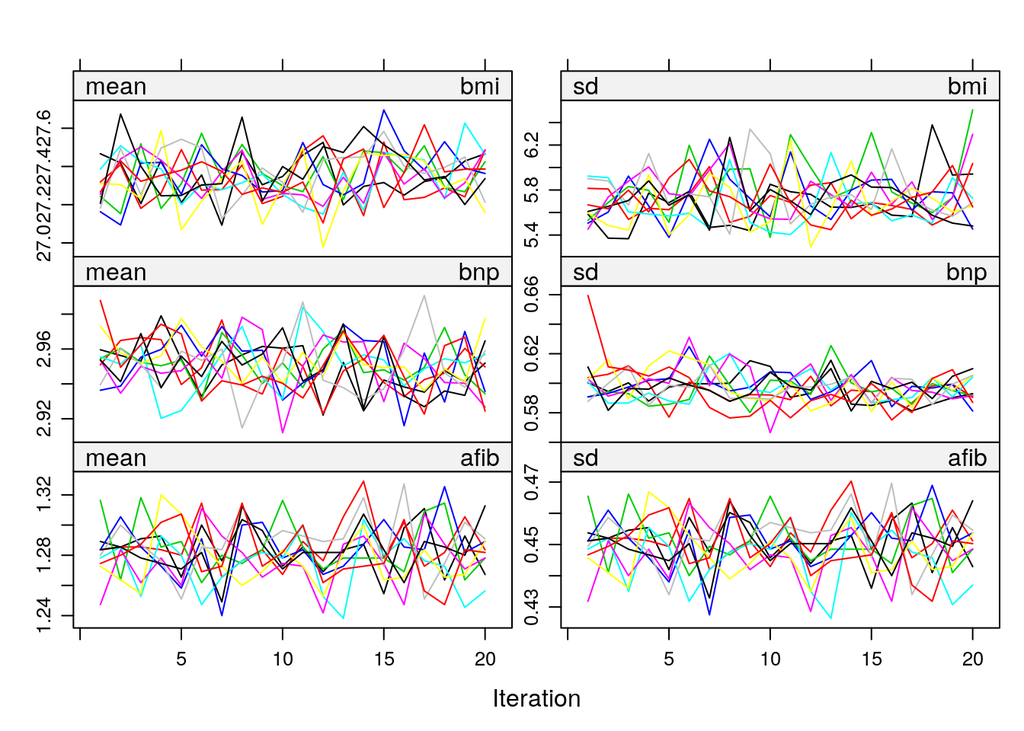

```r
# e. PRINT CONVERGENCE
plot(imp1l, y=var_monitor)
```

We can also extract the standard deviation of the random effects:

```r
naivestddev <- array(NA, dim=c(n_impute, 2))
colnames(naivestddev) <- c("(Intercept)", "bnp")
for (i in 1:length(mids1l$analyses)) {
  fiti <- mids1l$analyses[[i]]
  vc <- VarCorr(fiti)
  naivestddev[i,] <- attr(vc$centre, "stddev")
}
apply(naivestddev, 2, mean)
```

```
## (Intercept)         bnp
##  0.14319519  0.03221526
```

## Multiple imputation using FCS-2stage

We here adopt two-stage imputation that accounts for between-study heterogeneity in the intercept term, and the effect of BNP.

```r
# a. CONSTRUCT THE PREDICTOR MATIRX
pred <- imp1l$predict
pred[,"bnp"] <- 2
pred["bnp",] <- 2
pred[,"centre"] <- -2
pred[c("centre", "gender", "lvef"),] <- 0
diag(pred) <- 0
print(pred)
```

```
##        centre gender bmi age sbp dbp hr lvef bnp afib
## centre      0      0   0   0   0   0  0    0   0    0
## gender      0      0   0   0   0   0  0    0   0    0
## bmi        -2      1   0   1   1   1  1    1   2    1
## age        -2      1   1   0   1   1  1    1   2    1
## sbp        -2      1   1   1   0   1  1    1   2    1
## dbp        -2      1   1   1   1   0  1    1   2    1
## hr         -2      1   1   1   1   1  0    1   2    1
## lvef        0      0   0   0   0   0  0    0   0    0
## bnp        -2      2   2   2   2   2  2    2   0    2
## afib       -2      1   1   1   1   1  1    1   2    0
```

```r
# b. REDEFINE THE IMPUTATION METHODS
meth <- imp1l$method
meth[c("bmi", "age", "sbp", "dbp", "hr", "bnp")] <- "2l.2stage.norm"
meth["afib"] <- "2l.2stage.bin"
meth
```

```
##           centre           gender              bmi              age
##               ""               "" "2l.2stage.norm" "2l.2stage.norm"
##              sbp              dbp               hr             lvef
## "2l.2stage.norm" "2l.2stage.norm" "2l.2stage.norm"               ""
##              bnp             afib
## "2l.2stage.norm"  "2l.2stage.bin"
```

```r
# c. IMPUTE
if (!file.exists("../Data/great_impfcs2.RData") | refit) {
  impfcs2 <- mice(IPDNa, m = n_impute, maxit = maxit_impute, printFlag = FALSE, predictor = pred, method = meth)
  save(impfcs2, file="../Data/great_impfcs2.RData")

  midsfcs2 <- with(impfcs2, lmer(main_fmla_1stage))
  save(midsfcs2, file="../Data/great_midsfcs2.RData")
} else {
  load(file="../Data/great_impfcs2.RData")
  load(file="../Data/great_midsfcs2.RData")
}
```

The pooled estimates are as follows:

|  | estimate | std.error | statistic | df | p.value |
| --- | --- | --- | --- | --- | --- |
| (Intercept) | 0.6901228 | 0.0489686 | 14.093175 | 60.71887 | 0.00e+00 |
| bnp | -0.0982748 | 0.0142705 | -6.886576 | 48.28353 | 0.00e+00 |
| afib1 | 0.0299080 | 0.0056518 | 5.291732 | 23.20321 | 2.21e-05 |

We can also extract the standard deviation of the random effects:

```r
fcs2stddev <- array(NA, dim=c(n_impute, 2))
colnames(fcs2stddev) <- c("(Intercept)", "bnp")
for (i in 1:length(midsfcs2$analyses)) {
  fiti <- midsfcs2$analyses[[i]]
  vc <- VarCorr(fiti)
  fcs2stddev[i,] <- attr(vc$centre, "stddev")
}
apply(fcs2stddev, 2, mean)
```

```
## (Intercept)         bnp
##   0.1939175   0.0533170
```

Finally, we can inspect convergence:

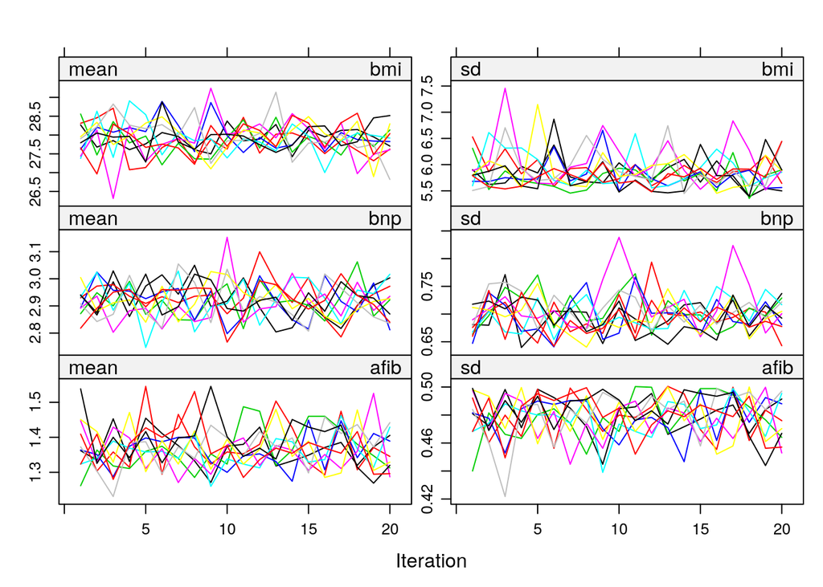

```r
# d. PRINT CONVERGENCE
plot(impfcs2, y=var_monitor)
```

## Multiple imputation using FCS-1stage

```r
# a. CONSTRUCT THE PREDICTOR MATIRX
pred <- impfcs2$predict
pred
```

```
##        centre gender bmi age sbp dbp hr lvef bnp afib
## centre      0      0   0   0   0   0  0    0   0    0
## gender      0      0   0   0   0   0  0    0   0    0
## bmi        -2      1   0   1   1   1  1    1   2    1
## age        -2      1   1   0   1   1  1    1   2    1
## sbp        -2      1   1   1   0   1  1    1   2    1
## dbp        -2      1   1   1   1   0  1    1   2    1
## hr         -2      1   1   1   1   1  0    1   2    1
## lvef        0      0   0   0   0   0  0    0   0    0
## bnp        -2      2   2   2   2   2  2    2   0    2
## afib       -2      1   1   1   1   1  1    1   2    0
```

```r
# b. REDEFINE THE IMPUTATION METHODS
meth <- impfcs2$method
meth[c("bmi", "age", "sbp", "dbp", "hr", "bnp")] <- "2l.glm.norm"
meth["afib"] <- "2l.glm.bin"
meth
```

```
##        centre        gender           bmi           age           sbp
##            ""            "" "2l.glm.norm" "2l.glm.norm" "2l.glm.norm"
##           dbp            hr          lvef           bnp          afib
## "2l.glm.norm" "2l.glm.norm"            "" "2l.glm.norm"  "2l.glm.bin"
```

```r
# c. IMPUTE
if (!file.exists("../Data/great_impfcs1.RData") | refit) {
  impfcs1 <- mice(IPDNa, m = n_impute, maxit = maxit_impute, printFlag = FALSE, predictor = pred, method = meth)
  save(impfcs1, file="../Data/great_impfcs1.RData")

  midsfcs1 <- with(impfcs1, lmer(main_fmla_1stage))
  save(midsfcs1, file="../Data/great_midsfcs1.RData")
} else {
  load(file="../Data/great_impfcs1.RData")
  load(file="../Data/great_midsfcs1.RData")
}
```

The pooled estimates are as follows:

|  | estimate | std.error | statistic | df | p.value |
| --- | --- | --- | --- | --- | --- |
| (Intercept) | 0.6810520 | 0.0379939 | 17.925281 | 128.58811 | 0.0000000 |
| bnp | -0.0968663 | 0.0120272 | -8.053906 | 50.25298 | 0.0000000 |
| afib1 | 0.0286138 | 0.0094392 | 3.031389 | 12.04311 | 0.0104017 |

We can also extract the standard deviation of the random effects:

```r
fcs1stddev <- array(NA, dim=c(n_impute, 2))
colnames(fcs1stddev) <- c("(Intercept)", "bnp")
for (i in 1:length(midsfcs1$analyses)) {
  fiti <- midsfcs1$analyses[[i]]
  vc <- VarCorr(fiti)
  fcs1stddev[i,] <- attr(vc$centre, "stddev")
}
apply(fcs1stddev, 2, mean)
```

```
## (Intercept)         bnp
##  0.16306141  0.04455934
```

Finally, we can inspect convergence:

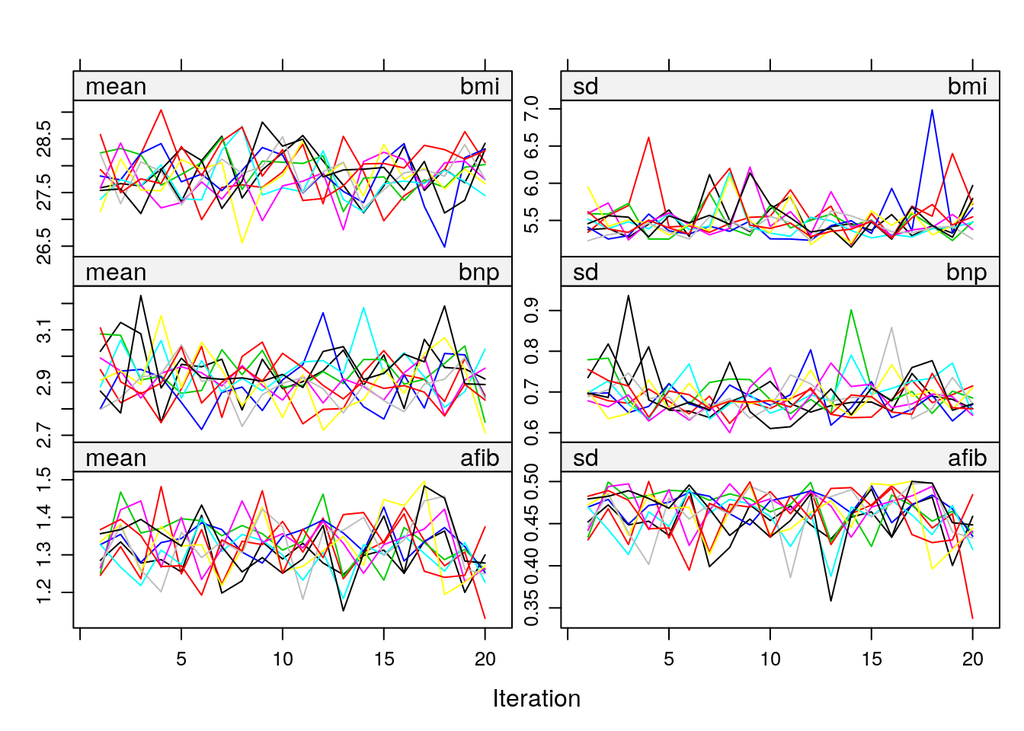

```r
# d. PRINT CONVERGENCE
plot(impfcs1, y=var_monitor)
```

## Multiple imputation using JOMO (common covariance)

```r
# c. Fit imputation model with common covariance matrix
if (!file.exists("../Data/great_impjm_common.RData") | refit) {
  impjm_common <- jomoImpute(formula = as.formula("bmi+age+sbp+dbp+hr+bnp+afib~gender+lvef+(1|centre)"),
                       random.L1 = "none",
                       m = n_impute,
                       data = IPDNa,
                       n.burn = n_burnin,
                       n.iter = n_between)
  save(impjm_common, file="../Data/great_impjm_common.RData")

  # Put results in a list in mitml format
  implist <- mitmlComplete(impjm_common, print=1:n_impute)

  # This is to fit analysis model on each imp
  midsjm_common <- with(implist, lmer("lvef ~ bnp + afib + (bnp|centre)"))
  save(midsjm_common, file="../Data/great_midsjm_common.RData")
} else {
  load(file = "../Data/great_impjm_common.RData")
  load(file = "../Data/great_midsjm_common.RData")
}

summary(impjm_common)
```

```
##
## Call:
##
## jomoImpute(data = IPDNa, formula = as.formula("bmi+age+sbp+dbp+hr+bnp+afib~gender+lvef+(1|centre)"),
##     random.L1 = "none", n.burn = n_burnin, n.iter = n_between,
##     m = n_impute)
##
## Cluster variable:         centre
## Target variables:         bmi age sbp dbp hr bnp afib
## Fixed effect predictors:  (Intercept) gender lvef
## Random effect predictors: (Intercept)
##
## Performed 10000 burn-in iterations, and generated 10 imputed data sets,
## each 5000 iterations apart.
##
## Potential scale reduction (Rhat, imputation phase):
##
##          Min   25%  Mean Median   75%   Max
## Beta:  1.000 1.000 1.006  1.000 1.001 1.104
## Psi:   1.000 1.000 1.015  1.001 1.008 1.094
## Sigma: 1.000 1.001 1.007  1.002 1.008 1.049
##
## Largest potential scale reduction:
## Beta: [1,6], Psi: [6,4], Sigma: [4,3]
##
## Missing data per variable:
##     centre bmi  age sbp dbp hr  bnp  afib gender lvef
## MD% 0      20.8 3.7 3.5 3.6 1.5 76.4 4.7  0      0
```

```r
# Rubin's rules (the option is to get level 2 variance)
fit.MI <- testEstimates(midsjm_common, var.comp = TRUE)
```

The pooled estimates can be derived from `fit.MI`, and are as follows:

|  | Estimate | Std.Error | t.value | df | P(>\|t\|) | RIV | FMI |
| --- | --- | --- | --- | --- | --- | --- | --- |
| (Intercept) | 0.6745218 | 0.0331925 | 20.32153 | 44.55128 | 0 | 0.8163988 | 0.4726157 |
| bnp | -0.0969413 | 0.0082151 | -11.80035 | 54.02802 | 0 | 0.6895956 | 0.4288991 |
| afib1 | 0.0247525 | 0.0037818 | 6.54524 | 182.11568 | 0 | 0.2858497 | 0.2307064 |

The between-study standard deviation of the intercept term and the regression coefficient of `bnp` are given as follows:

```r
# get SD of intercept variance
sqrt(fit.MI$var.comp["Intercept~~Intercept|centre","Estimate"])
```

```
## [1] 0.1178016
```

```r
# get SD of slope variance
sqrt(fit.MI$var.comp["bnp~~bnp|centre","Estimate"])
```

```
## [1] 0.02786947
```

## Multiple imputation using JOMO (with heteroscedasticity)

```r
# c. Fit imputation model with common covariance matrix
if (!file.exists("../Data/great_impjm_mean.RData") | refit) {
  impjm_mean <- jomoImpute(formula = as.formula("bmi+age+sbp+dbp+hr+bnp+afib~gender+lvef+(1|centre)"),
                       random.L1 = "mean",
                       m = n_impute,
                       data = IPDNa,
                       n.burn = n_burnin,
                       n.iter = n_between)
  save(impjm_mean, file="../Data/great_impjm_mean.RData")

  # Put results in a list in mitml format
  implist <- mitmlComplete(impjm_mean, print=1:n_impute)

  # This is to fit analysis model on each imp
  midsjm_mean <- with(implist, lmer("lvef ~ bnp + afib + (bnp|centre)"))
  save(midsjm_mean, file="../Data/great_midsjm_mean.RData")
} else {
  load(file = "../Data/great_impjm_mean.RData")
  load(file = "../Data/great_midsjm_mean.RData")
}

summary(impjm_mean)
```

[output not shown]

We can monitor convergence by analyzing the difference between multiple Markov chains. The convergence is assessed by comparing the estimated between-chains and within-chain variances for each model parameter. Large differences between these variances indicate nonconvergence. The potential scale reduction factor (PSRF) is defined as the ratio of the pooled variance (i.e. the total of the within- and between-chains variances) over the within-chain variance. The PSRF should be near 1 in case of convergence, and will be greater than 1 in case of non-convergence. Because JOMO only uses a single Markov chain, the PRSFs are computed by dividing each chain from the imputation phase into a number of sequences (3 by default).

The estimated potential scale reduction factor for each model parameter are given below

```r
impjm_mean_summary <- summary(impjm_mean)
impjm_mean_summary$conv
```

```
## $beta
##       i1 i2 grp     Rhat
##  [1,]  1  1   1 1.009597
##  [2,]  2  1   1 1.000090
##  [3,]  3  1   1 1.000063
##  [4,]  1  2   1 1.027004
##  [5,]  2  2   1 1.000243
##  [6,]  3  2   1 1.000384
##  [7,]  1  3   1 1.002771
##  [8,]  2  3   1 1.000668
##  [9,]  3  3   1 1.002097
## [10,]  1  4   1 1.002195
## [11,]  2  4   1 1.000188
## [12,]  3  4   1 1.001737
## [13,]  1  5   1 1.003869
```

[output cut: 73 more lines]

```r
fit.MI_mean <- testEstimates(midsjm_mean, var.comp = TRUE)
```

The pooled estimates are given as follows:

|  | Estimate | Std.Error | t.value | df | P(>\|t\|) | RIV | FMI |
| --- | --- | --- | --- | --- | --- | --- | --- |
| (Intercept) | 0.5927946 | 0.0347298 | 17.068772 | 5713.80888 | 0 | 0.0413282 | 0.0400239 |
| bnp | -0.0686170 | 0.0107162 | -6.403138 | 9771.02093 | 0 | 0.0312994 | 0.0305479 |
| afib1 | 0.0274194 | 0.0043503 | 6.302854 | 59.81673 | 0 | 0.6336964 | 0.4073799 |

The between-study standard deviation of the intercept term and the regression coefficient of `bnp` are given as follows:

```r
# get SD of intercept variance
sqrt(fit.MI_mean$var.comp["Intercept~~Intercept|centre","Estimate"])
```

```
## [1] 0.1732048
```

```r
# get SD of slope variance
sqrt(fit.MI_mean$var.comp["bnp~~bnp|centre","Estimate"])
```

```
## [1] 0.05347915
```

When inspecting convergence, it can be seen that a couple of parameters have not yet converged, which is likely given how many covariance matrix parameters we have with this model. (this should be around 30*8*8/2). Although this may not much have affected the results, increasing the number of iterations may be preferred.